# project-1-checkpoint3

# CSV

In a .csv file already, so it could not be scraped, but I thought it would be interesting.

## Measles Vaccine (1st Dose) Immunization

**Data Description:** The WHO has data on measles containing vaccine first-dose (MCV1) immunization coverage among one year olds.

**Motivation:** Measles is highly contagious, with children under five facing the greatest risk of severe health complications. As a result, examining global coverage rates for the first dose of the measles vaccine is especially important.

**Source:** https://www.who.int/data/gho/data/indicators/indicator-details/GHO/measles-containing-vaccine-first-dose-(mcv1)-immunization-coverage-among-1-year-olds-(-)

https://www.cdc.gov/measles/about/index.html

```r
mcv <-read_csv(here::here("data", "mcv1.csv"))

mcv <- mcv |>
  select(SpatialDimValueCode, Period, Value) |>
  rename("Country Code" = SpatialDimValueCode,
         "MCV1 Coverage" = Value,
         "MCV1 Year" = Period)

# pivot to make clearer
measles_year_clean <- measles_year_clean |>
  left_join(mcv, by = join_by("Country Code", "Year" == "MCV1 Year"))
```

## Visualization

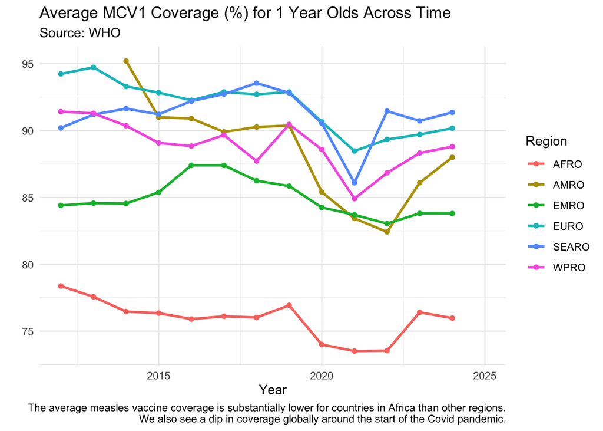

```r
measles_year_clean |>
  group_by(Region, Year) |>
  summarise(mean_coverage = mean(`MCV1 Coverage`, na.rm = TRUE),
            .groups = "drop") |>
  ggplot(aes(x = Year, y = mean_coverage, color = Region)) +
  geom_line(linewidth = 1) +
  geom_point() +
  labs(title = "Average MCV1 Coverage (%) for 1 Year Olds Across Time",
       subtitle = "Source: WHO",
       y = "",
       x = "Year",
       caption = "The average measles vaccine coverage is substantially lower for countries in Africa than other regions.
       We also see a dip in coverage globally around the start of the Covid pandemic.") +
  theme_minimal()
```

## Join and Clean Final Dataset

```r
measles_year_clean <- measles_year_clean |>
  rename(`Gini Year` = gini_year,
         `Gini Value` = gini_value,
         "Latitude" = geolocation_latitude,
         "Longitude" = geolocation_longitude,
         "Religion" = religion_name,
         "Religion Pop." = religion_population,
         "Pct Religious" = religion_percentage,
         "Govt. Type" = government_type,
         "HDI" = hdi,
         "Borders" = borders,
         "Area" = area,
         "Govt. Leaders" = government_leaders)

# clean gini data
gini_data <- measles_year_clean |>
  select(`Gini Year`, `Gini Value`, `Country Code`, "Year")

measles_year_clean <- measles_year_clean |>
  select(-c(`Gini Year`, `Gini Value`))

gini_data <- gini_data |>
  unnest(cols = c(`Gini Year`, `Gini Value`)) |>
  mutate(
    `Gini Year` = as.numeric(as.character(`Gini Year`)),
    `Gini Value` = as.numeric(as.character(`Gini Value`))) |>
  filter(Year == `Gini Year`) |>
  select(`Country Code`, Year, `Gini Value`)

measles_final <- measles_year_clean |>
  left_join(gini_data, by = c("Country Code", "Year"))
```

## Final Dataset

```r
head(measles_final)
```

```
# A tibble: 6 × 29
  Region Country `Country Code`  Year `Total Pop.` `Total Suspected Cases`
  <chr>  <chr>   <chr>          <dbl>        <dbl>                   <dbl>
1 AFRO   Algeria DZA             2013     38414172                      85
2 AFRO   Algeria DZA             2014     39205031                      49
3 AFRO   Algeria DZA             2015     40019529                     109
4 AFRO   Algeria DZA             2016     40850721                      93
5 AFRO   Algeria DZA             2017     41689299                     314
6 AFRO   Algeria DZA             2018     42505035                     345
# ℹ 23 more variables: `Total Measles` <dbl>, `Total Lab Measles` <dbl>,
#   `Total Epi Measles` <dbl>, `Total Clinical Measles` <dbl>,
#   `Total Measles per Million` <dbl>, `Total Discarded` <dbl>,
#   `Total Discarded per Million` <dbl>, `Avg. Celsius` <dbl>,
#   `Avg. Fahrenheit` <dbl>, `Life Expectancy 2024` <int>, Latitude <dbl>,
#   Longitude <dbl>, Religion <list<chr>>, `Religion Pop.` <list<int>>,
#   `Pct Religious` <list<dbl>>, `Govt. Type` <chr>, …
```

```r
# save to csv
measles_final |>
  write_csv("measles_final.csv")
```